# Import Libraries

```python
from sklearn.neighbors import LocalOutlierFactor
from sklearn.linear_model import LogisticRegressionCV
from sklearn.metrics import classification_report
from sklearn.preprocessing import MinMaxScaler,OneHotEncoder
import numpy as np
from numpy import quantile, where
from sklearn.model_selection import train_test_split
import pandas as pd
import matplotlib.pyplot as plt
import pickle
from sklearn.metrics import roc_curve,roc_auc_score
from sklearn.cluster import KMeans
import seaborn as sns
%matplotlib inline
```

# Tax Fraud Analysis

We are going to use the Value Added Tax Dataset collected from multiple taxpayers to conduct Tax Analysis. We will perform Exploratory Data Analysis (EDA) and then clean the data to prepare it for further analysis, ensuring a clean dataset.

# Understanding the Data

Let's start by reading in the VAT_Dataset.csv file into a pandas dataframe.

```python
# getting the dataset from google drive
data = pd.read_csv("https://drive.google.com/uc?export=download&id=1ajzIwFxXsp5QRmk49ilZFfU3nAxQTPby")
```

```python
data.head()
```

|  | RETURN_ID | TPIN | RETURN_AMOUNT | NUMBER_OF_OUTPUT_INVOICES | SUM_OF_OUTPUT_INVOICES | NUMBER_OF_INPUT_INVOICES | SUM_OF_INPUT_INVOICES | REFUND_STATUS | REFUND_AMOUNT_CLAIMED | REFUND_AMOUNT_PAID | REFUND_ID | CREDIT_RETURN | REFUND_CREATED | REFUND_APPROVED | REJECTED_REFUNDS |
| --- | --- | --- | --- | --- | --- | --- | --- | --- | --- | --- | --- | --- | --- | --- | --- |
| 0 | 6458.0 | 1.002031e+09 | 2898.89 | 0.0 | 0.00 | 2.0 | 18118.08 | NaN | NaN | NaN | NaN | 0.0 | 0.0 | 0.0 | NaN |
| 1 | 7219.0 | 1.003131e+09 | 6064.15 | 0.0 | 0.00 | 2.0 | 0.00 | NaN | NaN | NaN | NaN | 0.0 | 0.0 | 0.0 | NaN |
| 2 | 7371.0 | 1.001976e+09 | 479.50 | 4.0 | 25477.99 | 3.0 | 28474.88 | NaN | NaN | NaN | NaN | 0.0 | 0.0 | 0.0 | NaN |
| 3 | 7608.0 | 1.001787e+09 | 1205.01 | 0.0 | 0.00 | 1.0 | 7531.31 | NaN | NaN | NaN | NaN | 0.0 | 0.0 | 0.0 | NaN |
| 4 | 7700.0 | 1.005474e+09 | -112.30 | 36.0 | 78730.82 | 106.0 | 139275.41 | FULLY_PAID_MANUALLY | 112.3 | 112.3 | 1588.0 | 1.0 | 1.0 | 1.0 | 0.0 |

```python
data.info()
```

```
<class 'pandas.core.frame.DataFrame'>
RangeIndex: 229121 entries, 0 to 229120
Data columns (total 15 columns):
 #   Column                     Non-Null Count   Dtype
---  ------                     --------------   -----
 0   RETURN_ID                  229120 non-null  float64
 1   TPIN                       229120 non-null  float64
 2   RETURN_AMOUNT              229120 non-null  float64
 3   NUMBER_OF_OUTPUT_INVOICES  229120 non-null  float64
 4   SUM_OF_OUTPUT_INVOICES     229120 non-null  float64
 5   NUMBER_OF_INPUT_INVOICES   229120 non-null  float64
 6   SUM_OF_INPUT_INVOICES      229120 non-null  float64
 7   REFUND_STATUS              17899 non-null   object
 8   REFUND_AMOUNT_CLAIMED      17899 non-null   float64
 9   REFUND_AMOUNT_PAID         17899 non-null   float64
 10  REFUND_ID                  17899 non-null   float64
 11  CREDIT_RETURN              229120 non-null  float64
 12  REFUND_CREATED             229120 non-null  float64
 13  REFUND_APPROVED            229119 non-null  float64
 14  REJECTED_REFUNDS           17897 non-null   float64
dtypes: float64(14), object(1)
memory usage: 26.2+ MB
```

# Exploratory Data Analysis

Let's begin some exploratory data analysis! We'll start by checking out missing data!

## Missing Data

We can use seaborn to create a simple heatmap to see where we are missing data!

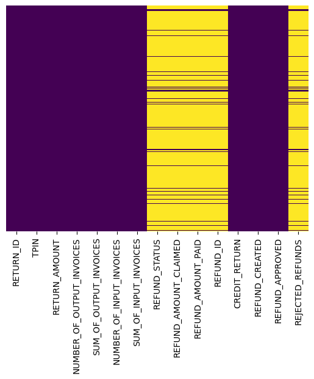

```python
sns.heatmap(data.isnull(),yticklabels=False,cbar=False,cmap='viridis')
```

# Duplicates TPIN

lets check if they are duplicate tpin

```python
duplicates = data[data.duplicated(subset=['TPIN'], keep=False)]
duplicates.info()
```

```
<class 'pandas.core.frame.DataFrame'>
Index: 228199 entries, 1 to 229120
Data columns (total 15 columns):
 #   Column                     Non-Null Count   Dtype
---  ------                     --------------   -----
 0   RETURN_ID                  228199 non-null  float64
 1   TPIN                       228199 non-null  float64
 2   RETURN_AMOUNT              228199 non-null  float64
 3   NUMBER_OF_OUTPUT_INVOICES  228199 non-null  float64
 4   SUM_OF_OUTPUT_INVOICES     228199 non-null  float64
 5   NUMBER_OF_INPUT_INVOICES   228199 non-null  float64
 6   SUM_OF_INPUT_INVOICES      228199 non-null  float64
 7   REFUND_STATUS              17833 non-null   object
 8   REFUND_AMOUNT_CLAIMED      17833 non-null   float64
 9   REFUND_AMOUNT_PAID         17833 non-null   float64
 10  REFUND_ID                  17833 non-null   float64
 11  CREDIT_RETURN              228199 non-null  float64
 12  REFUND_CREATED             228199 non-null  float64
 13  REFUND_APPROVED            228198 non-null  float64
 14  REJECTED_REFUNDS           17831 non-null   float64
dtypes: float64(14), object(1)
memory usage: 27.9+ MB
```

From the above we can see that we have 228199 tpin are duplicates out of 229120 tpins, which means only 921 are not duplicate. Looke close to see what the duplicates data tells.

```python
# Converting the 'TPIN' column to integer using .loc to modify the original DataFrame
duplicates.loc[:, 'TPIN'] = duplicates['TPIN'].astype(int)

# Sorting the DataFrame by 'TPIN' column in ascending order
sorted_duplicates = duplicates.sort_values(by='TPIN')

# Getting the last 5 rows
sorted_duplicates.tail(4)
```

|  | RETURN_ID | TPIN | RETURN_AMOUNT | NUMBER_OF_OUTPUT_INVOICES | SUM_OF_OUTPUT_INVOICES | NUMBER_OF_INPUT_INVOICES | SUM_OF_INPUT_INVOICES | REFUND_STATUS | REFUND_AMOUNT_CLAIMED | REFUND_AMOUNT_PAID | REFUND_ID | CREDIT_RETURN | REFUND_CREATED | REFUND_APPROVED | REJECTED_REFUNDS |
| --- | --- | --- | --- | --- | --- | --- | --- | --- | --- | --- | --- | --- | --- | --- | --- |
| 202514 | 4260372.0 | 2146014640 | 561.65 | 5.0 | 44289.65 | 5.0 | 47800.00 | NaN | NaN | NaN | NaN | 0.0 | 0.0 | 0.0 | NaN |
| 200544 | 4169252.0 | 2146014640 | 578.65 | 3.0 | 62923.45 | 4.0 | 66540.00 | NaN | NaN | NaN | NaN | 0.0 | 0.0 | 0.0 | NaN |
| 215798 | 4523746.0 | 2146014640 | 366.67 | 1.0 | 15948.00 | 1.0 | 18239.66 | NaN | NaN | NaN | NaN | 0.0 | 0.0 | 0.0 | NaN |
| 225958 | 4815999.0 | 2146014640 | 405.69 | 10.0 | 31764.35 | 5.0 | 34300.00 | NaN | NaN | NaN | NaN | 0.0 | 0.0 | 0.0 | NaN |

With further analysis, we've gained deeper insights into the duplicate TPINs. While the TPINs are duplicated, the values in the other columns are distinct. These duplicates arise from instances where taxpayers have paid the VAT tax multiple times.

### Let's continue the EDA on by **Visualisation** some more of the data!

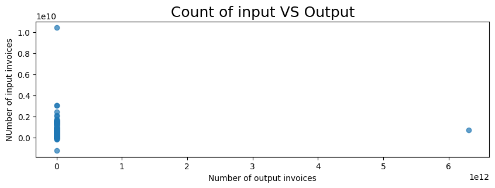

```python
plt.figure(figsize=(10,3))
plt.scatter(data['SUM_OF_OUTPUT_INVOICES'],data['SUM_OF_INPUT_INVOICES'],alpha=0.7)
plt.xlabel('Number of output invoices')
plt.ylabel('NUmber of input invoices')
plt.title('Count of input VS Output',size=18)
```

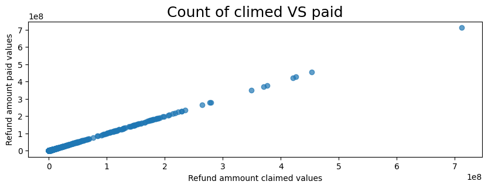

```python
plt.figure(figsize=(10,3))
plt.scatter(data['REFUND_AMOUNT_CLAIMED'],data['REFUND_AMOUNT_PAID'],alpha=0.7)
plt.xlabel('Refund ammount claimed values')
plt.ylabel('Refund amount paid values')
plt.title('Count of climed VS paid',size=18)
```

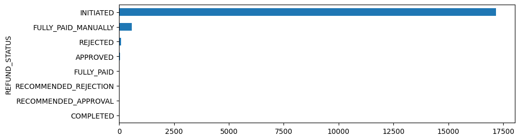

```python
plt.figure(figsize=(10,3))
data['REFUND_STATUS'].value_counts().sort_values(ascending=True).plot(kind='barh')
```

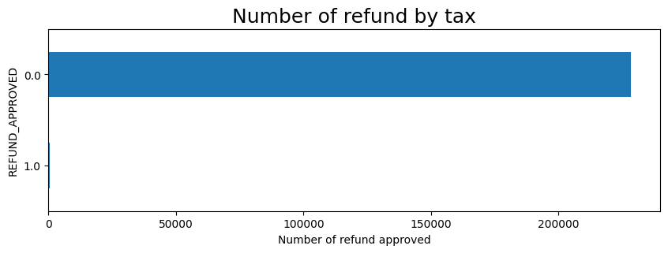

```python
plt.figure(figsize=(10,3))
data['REFUND_APPROVED'].value_counts().sort_values(ascending=True).plot(kind='barh')
plt.xlabel('Number of refund approved')
plt.title('Number of refund by tax',size=18)
```

## Data Cleaning

We aim to clean the missing data, and upon inspection, we've identified 5 columns containing missing values. Specifically, we need to address the missing data in the REFUND_STATUS column. To do so, we'll fill in the missing REFUND_STATUS data with the corresponding values for each status. For instance, where the status is 'APPROVED', missing values will be filled with 6; where there are NaN values, they'll be replaced with 0. We'll apply similar logic for the other possible statuses since REFUND_STATUS can have multiple values.

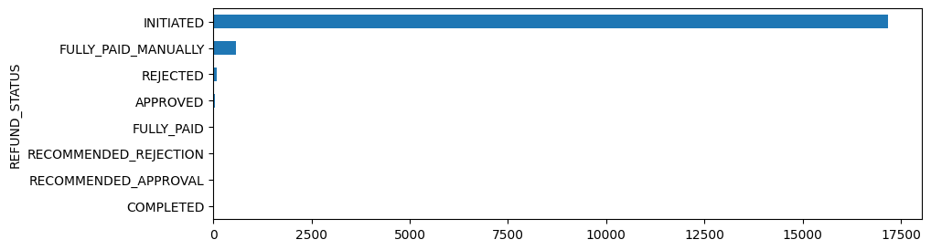

```python
plt.figure(figsize=(10,3))
data['REFUND_STATUS'].value_counts().sort_values(ascending=True).plot(kind='barh')
```

```python
# Define the mapping of statuses to numeric values

status_mapping = {
    'FULLY_PAID_MANUALLY': 1,
    'INITIATED': 2,
    'REJECTED': 3,
    'FULLY_PAID': 4,
    'RECOMMENDED_APPROVAL': 5,
    'APPROVED': 6,
    'COMPLETED': 7,
    'RECOMMENDED_REJECTION': 8
}

# Replace NaN with 0 and map the statuses to numeric values
data['REFUND_STATUS'] = data['REFUND_STATUS'].map(status_mapping).fillna(0)
```

Upon examining the missing data in other columns such as REFUND_AMOUNT_CLAIMED, REFUND_AMOUNT_PAID, and REJECTED_REFUNDS, we observe that the missing values may be due to scenarios where the taxpayer did not claim a refund or the refund was not approved. Instead of dropping these columns, we can address the missing data (NaNs) by filling them with zero.

```python
# Assuming data is your DataFrame
columns_to_fill = ['REFUND_AMOUNT_CLAIMED', 'REFUND_AMOUNT_PAID', 'REJECTED_REFUNDS']

# Fill NaN values with zero for specified columns
data[columns_to_fill] = data[columns_to_fill].fillna(0)
```

Upon examining the data, we've identified that the columns TPIN, RETURN_ID, and REFUND_ID contain values that are either increasing numbers or constants, which do not provide any meaningful value for data analysis or model creation. To improve our analysis, we will take the following steps:

```python
# Drop rows where TPIN is missing
data.dropna(subset=['TPIN'], inplace=True)

# Remove the columns RETURN_ID and REFUND_ID
data.drop(columns=['RETURN_ID', 'REFUND_ID'], inplace=True)
```

The data has been cleaned and is now ready for further analysis, such as generating a heatmap to show correlation between the columns.

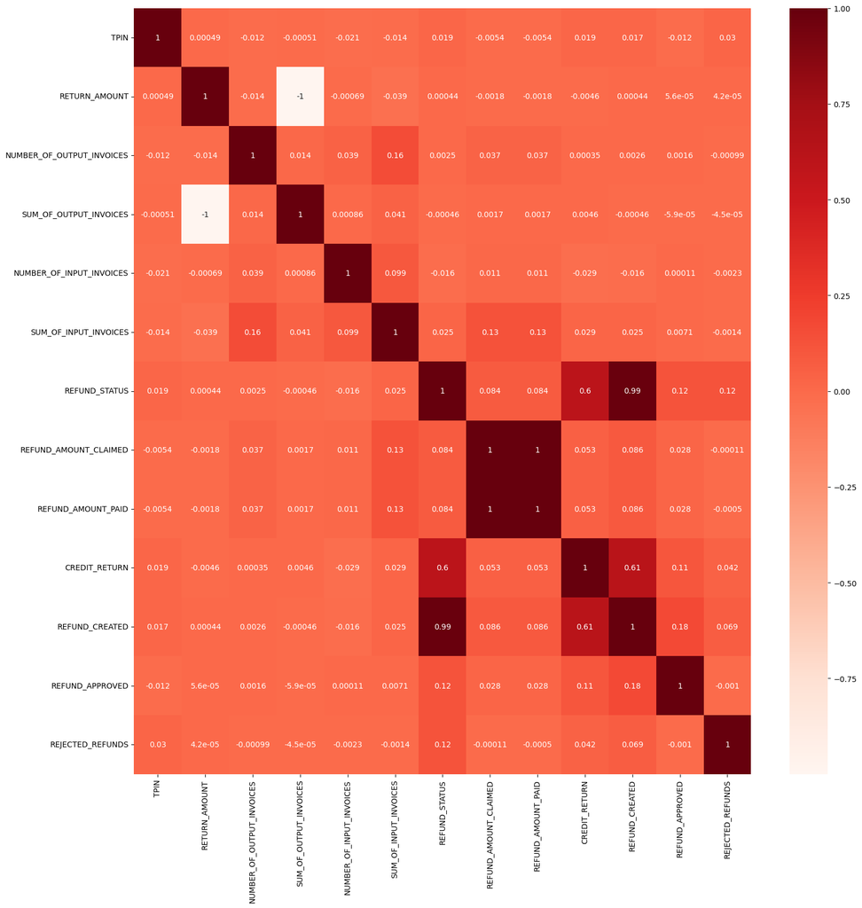

```python
import seaborn as sns
plt.figure(figsize=(18,18))
cor = data.corr()
sns.heatmap(cor, annot=True, cmap=plt.cm.Reds)
plt.show()
```

# SAVING THE CLEAN DATASET

```python
data.to_csv('clean_vat_data_v1.csv', index=False)
```